# Open Scholarship Tools

a whirlwind tour

Martin Fenner [@mfenner](https://twitter.com/mfenner)

Ian Mulvany [@ianmulvany](https://twitter.com/ianmulvany)

# Overview

- DOI or how to "cite this" in academia
- Git yourself in control of all the changes
- Look around you, how to visualise your data
- bringing it all together

# Digital object identifiers (DOIs)

## How does a DOI look like

**10.x/y** where x is 4-5 digits (and 10.x is the DOI prefix) and y (the suffix) can be anything.

- http://dx.doi.org/10.5555/12345678 or **10.5555/12345678**
- http://doi.org/hvx or **10/hvx**
- http://hdl.handle.net/10/hvx
- http://hdl.handle.net/1721.1/26698 or **1721.1/26698**

## The basics

- DOIs are persistent identifiers: the idenfier is independent of the location, can be resolved, and the organization issueing the identifier guarantees its long-term availabibility
- DOIs have attached metadata
- DOIs support a centralized citation tracking service. A scholarly citation is basically **persistent identifier (e.g. DOI)** + **metadata** + **link a -> b**

http://api.crossref.org/funders/10.13039/100000001/works?filter=license.url:http://creativecommons.org/licenses/by/3.0/deed.en_US

## Some things you might not have known: not every DOI is the same.

There are 9 different DOI registration agencies. Not all of them register scholarly content, e.g. the [Publications Office of the European Union (OP)](http://publications.europa.eu/index_en.htm) and the [Entertainment Identifier Registry (EIDR)](http://www.eidr.org/) do not.

Different services can be built using DOIs, the reason the registration agency CrossRef was started was to facilitate citation linking between many publishers

Some of the functionality is a service of the registration agency - metadata search for example is offered by CrossRef (http://search.crossref.org) and DataCite (http://search.datacite.org)

To find out what registration agency registered a DOI, use http://api.crossref.org/works/10.6084/m9.figshare.821213/agency

## DOIs are URLs

[DOI names may be expressed as URLs (URIs) through a HTTP proxy server](http://www.doi.org/faq.html) - e.g. http://dx.doi.org/10.5555/12345679 , and this is how DOIs are typically resolved. Because DOIs can be expressed as URLs

- avoid special characters, e.g. as in this SICI DOI: **10.4567/0361-9230(1997)42:2.0.TX;2-B**
- [content negotiation](http://www.crosscite.org/cn/) to get to the metadata instead of being forwarded to the resource
- fragment identifiers, e.g. http://dx.doi.org/10.1371/journal.pone.0103437#s2 or http://doi.org/10.5446/12780#t=00:20,00:27

# GIT

# why git

- a large number of tools for open scholarship are hosted on github
- github is powered by git
- you need to know about git

# For those who don't know Git ...

# what is git?

- git is a piece of software that tracks changes in files
- created in 2005 by Linus torvalds, the creator of the Linux kernel
- it's a bit like Gandalf

-- a little bit magical

-- fast

-- decentralised

-- open source

-- opinionated

-- cryptic

-- powerful

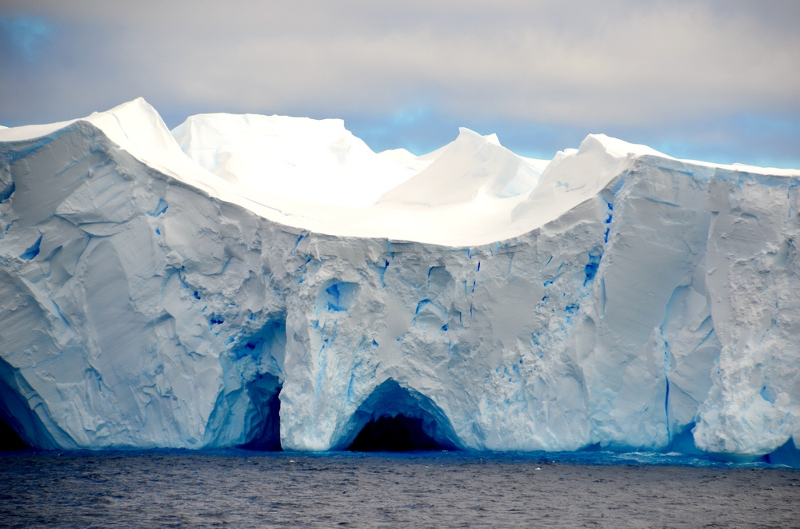

```python
i
```

```python
f
```

[figure not shown]

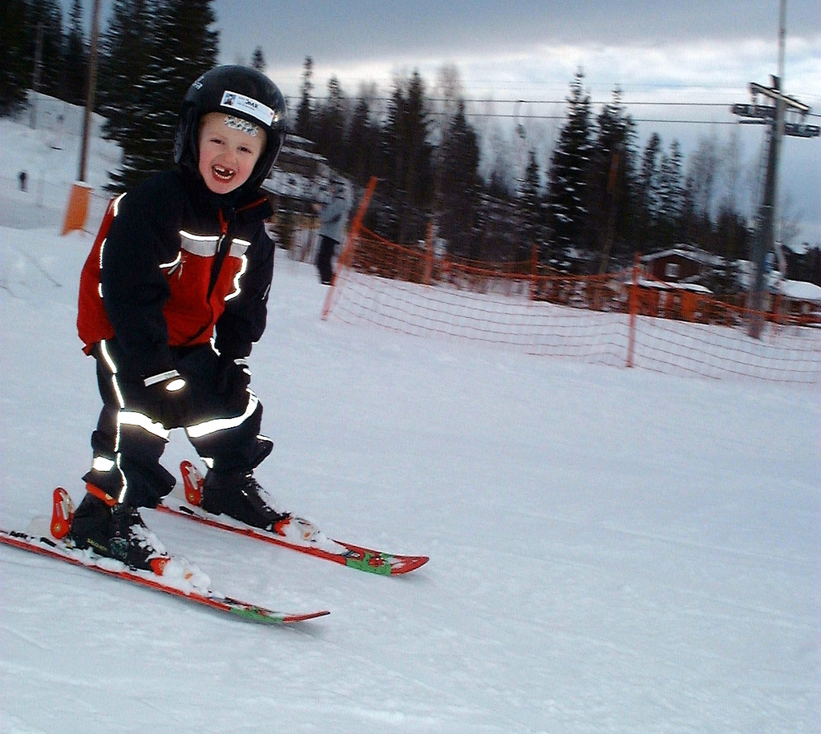

```python
happy
```

Image CC-BY-NC-SA Ola Lindberg Flickr

# how to get started

- install [git](http://git-scm.com)
- this talk is available in github, clone it and start playing around  
  git clone git@github.com:IanMulvany/wikimania-open-scholarship-tools.git

# A lexicon for the confused

- a repo, or repository <-—> your software
- cloning a repo <-—> making a copy of your software
- a branch <-—> a version of your software, different versions can do different things
- a commit <-—> adding some code to your software
- a pull request <-—> asking if you can send something to someone

```python
HTML('<iframe src="http://gitready.com" width=600 height=400></iframe>')
# http://gitready.com
```

[interactive chart not shown]

## https://help.github.com

```python
HTML('<iframe src="https://mac.github.com" width=600 height=400></iframe>')
# https://mac.github.com
```

[interactive chart not shown]

# So you know git already, but did you know ...

# here are some of my favourite git/github tips and tricks

- use github for code review
- when you send a pull request to a branch, up to the point when that branch gets merged, any of your commits that you push to your remote automatically turn up in the pull request, making this a fantastic workflow for discussing and reviewing code
- there is a magic tip to ignore white space when looking at diffs in github
- you can customise the bejasus out of your git terminal command line, I don't understand git well enough to figure out how to do this myself, but here are some that I like that [I have copied from t'internet](http://partiallyattended.com/2014/08/09/git-command-line-shortcuts/)

# Science resources on github

```python
HTML('<iframe src="https://guides.github.com/activities/citable-code/" width=600 height=400></iframe>')
# https://guides.github.com/activities/citable-code/
```

[interactive chart not shown]

[figure not shown]

```python
tools
```

# A shout out to some specific tools

### https://osf.io

### https://github.com/CenterForOpenScience/openscienceframework.org

### https://peerlibrary.org/s

### https://github.com/peerlibrary/peerlibrary

## http://sciencetoolbox.org

# https://github.com/elifesciences/lens

## https://github.com/OpenElectrophy/OpenElectrophy

## https://github.com/articlemetrics/alm/

## https://github.com/biopython/biopython

# Visualisation - telling stories with data

## Learn the Basics

Work on visualization of scientific data should start with a good understanding of the best practices and pitfalls of data visualization in general, as well as the specific aspects of visualizing scientific data.

- [Visualize this](http://book.flowingdata.com/) - book on chart types, tools and tricks
- [D3 Gallery](https://github.com/mbostock/d3/wiki/Gallery) - Examples
- [ggplot2](http://docs.ggplot2.org/current/index.html) - the grammar of graphics, and an implementation in R

## Learn to use at least one visualization tool

Excel, [R](http://www.rstudio.com/), [d3.js](http://d3js.org/), [Datawrapper](https://datawrapper.de/), [Prism](http://www.graphpad.com/scientific-software/prism/), ...

## Learn data analysis

You need to know at least the basics of data analysis to do proper data visualizations, e.g. how to handle wrongly formatted data (e.g. text in a number column), missing values and outliers.

Data analysis becomes much easier with a dedicated data analysis language such as R, Python or Julia

The most time-consuming step in my experience is **data transformation**, i.e. bringing data into the format that you want for the analysis and visualization.

## Use a vector file format

Bitmap graphic formats such as `tiff`, `jpg` and `png` are not appropriate for charts. Use vector formats such as `svg` or `pdf`, and make the data underlying the figure available.

## Get inspired by great visualizations

We should become more creative with visualizing data in scholarly documents. These graphs often focus too much on detail rather than the overall message, don't take advantage of the different chart types available, and are sometimes even misleading

One important step towards that goal is publishers accepting more reasonable file formats for figures coming with submitted manuscript - instead of just `tiff` and `eps`, and with a 10 MB file size limit.

# Interactive demo

```python
HTML('<iframe src="http://ipython.org/notebook.html" width=600 height=400></iframe>')
```

[interactive chart not shown]

# Code examples!!

```python
# get recent DOIs deposited by PLOS using the CrosRef API
import requests
url = "http://api.crossref.org/members/340/works?filter=from-update-date:2014-07-21,until-update-date:2014-07-24&rows=1000"
r = requests.get(url)
```

```python
# extract the dois from the API response
dois = get_dois_from_response(r)
print (dois[0:3])
```

```
[u'10.1371/journal.pone.0102119.g004', u'10.1371/journal.pone.0102130.s001', u'10.1371/journal.pone.0102119.t001']
```

```python
# just get the top level DOIS
parent_dois = get_parent_dois(dois)
print (parent_dois[0:3])
```

```
[u'10.1371/journal.pone.0102119', u'10.1371/journal.pone.0102130', u'10.1371/journal.pone.0102119']
```

```python
unique_dois = get_unique_dois(parent_dois)
print (unique_dois[0:3])
```

```
[u'10.1371/journal.pone.0102119', u'10.1371/journal.pone.0102130', u'10.1371/journal.pone.0102076']
```

```python
# now we import an interface to the PLOS ALM app
import pyalm.pyalm as alm
```

```python
article_data = {}
for doi in unique_dois:
    try:
        article = alm.get_alm(str(doi), info="summary")
        article_mendeley = alm.get_alm(str(doi), info="event", source="mendeley")
        mendeley_metrics = article_mendeley[0].sources["mendeley"].metrics.total
        article_data[doi] = {"views":article[0].views, "citations":article[0].citations, "mendeley": mendeley_metrics}
    except:
        print "no data for ", doi
```

```python
values = article_data.values()
def get_views(x): return x["views"]
def get_cites(x): return x["citations"]
def get_mendeley(x): return x["mendeley"]
all_views = map(get_views, values)
all_cites = map(get_cites, values)
all_mendeley = map(get_mendeley, values)
print values[0:3]
print all_views[0:3]
print all_cites[0:3]
print all_mendeley[0:3]
```

```
[{'mendeley': 0, 'citations': 0, 'views': 164}, {'mendeley': 1, 'citations': 0, 'views': 415}, {'mendeley': 0, 'citations': 0, 'views': 127}]
[164, 415, 127]
[0, 0, 0]
[0, 1, 0]
```

```python
import matplotlib.pyplot as plt
import numpy as np
```

```
<Container object of 118 artists>
```

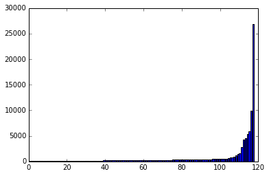

```python
fig, ax = plt.subplots(1, 1)
sorted_views = all_views.sort()
ax.bar(pos,all_views)
```

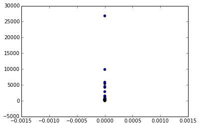

```python
fig, ax = plt.subplots(1, 1)
ax.scatter(all_cites,all_views)
```

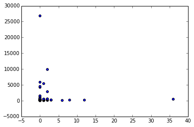

```python
fig, ax = plt.subplots(1, 1)
ax.scatter(all_mendeley,all_views)
```

```python
HTML('<iframe src="http://londonopendrinks.org" width=600 height=400></iframe>')
# http://londonopendrinks.org
```

[interactive chart not shown]